# A post-hoc analysis comparing the first week of sampling (no lure) to all other weeks of sampling

Mason Fidino

This supplemental material uses all of the same models, data, and code for the original lure analysis save for the fact that `./data/lure_position.csv` has been modified to compare the first week to all other weeks of sampling. In the original model, the first six rows of`lure_position.csv` looks like:

```
##   V1 V2 V3 V4
## 1  0  1  1  0
## 2  0  1  0  1
## 3  0  1  1  0
## 4  0  1  0  1
## 5  0  1  1  0
## 6  0  1  0  1
```

where each row indicates a camera, and every two rows is a new sampling unit. When a lure is present in front of a camera the cell takes the value 1, otherwise it is 0. Each column represents a new week of sampling. We created a new design matrix for this post-hoc analysis, `./data/lure_position_posthoc.csv` where the first column is all 0 values and the remaining three columns are filled with 1’s.

```
##   V1 V2 V3 V4
## 1  0  1  1  1
## 2  0  1  1  1
## 3  0  1  1  1
## 4  0  1  1  1
## 5  0  1  1  1
## 6  0  1  1  1
```

Following this, we reran `fit_exponential_model.R`, `fit_binomial_mode.R`, and `fit_poisson_model.R` save for the fact that we used this new design matrix. Below, we compare the parameter estimates from the first modeling approach to this secondary analysis for each species.

```r
#first_analysis <- readRDS("fit_binomial_model.R")
```

### The exponential model

```r
analysis_1 <- readRDS("exponential_results.RDS")
analysis_2 <- readRDS("exponential_results_posthoc.RDS")
```

#### Eastern gray squirrel results

The probability of occupancy estimated between both models were near identical.

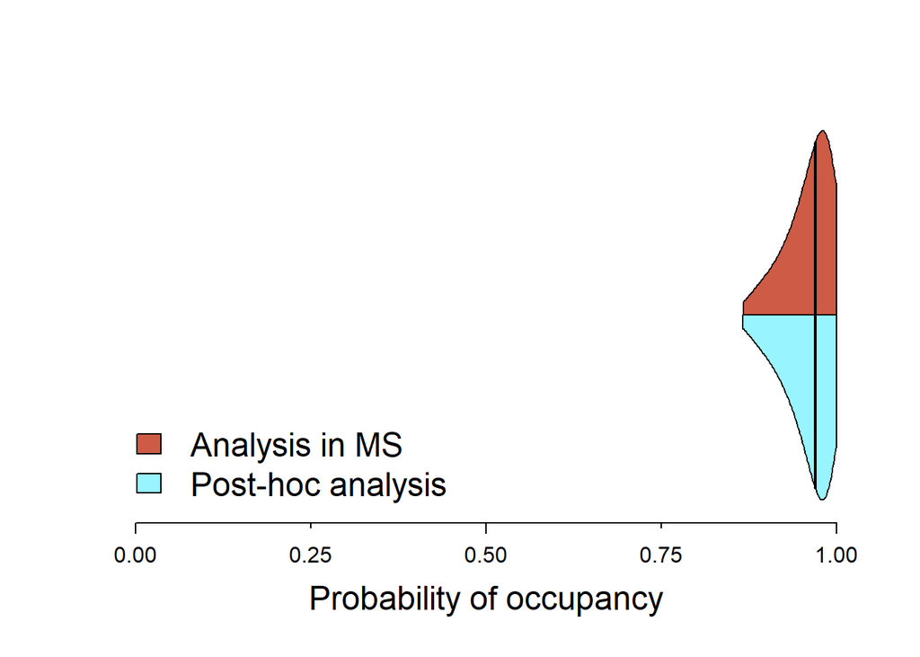